# 词嵌入及应用

## 一、 实验目的

### 1. 调用两种基本词嵌入算法 skipgram 和 CBOW，并对结果进行对比和评估。

### 2. 掌握词嵌入在分类和聚类中的基本应用，了解预训练词嵌入的适用范围。

## 二、实验内容

### 1.调用 gensim 得到词嵌入向量。

a. 对 20newsgroups 子集 multi3 和 multi5 调用 gensim 得到skipgram 词嵌入向量。假设维度 100， 窗口大小：5。

```python
import nltk
from gensim.models import word2vec
import pandas as pd
from sklearn.datasets import fetch_20newsgroups

# 加载数据集
data = fetch_20newsgroups(subset='all', shuffle=True, remove=('headers', 'footers', 'quotes'))

# 创建标签名字典
data_labels_map = dict(enumerate(data.target_names))

# 提取语料库和目标标签以及目标名称
corpus, target_labels, target_names = (data.data, data.target, [data_labels_map[label] for label in data.target])

# 创建Pandas DataFrame
data_df = pd.DataFrame({'Article': corpus, 'Target Label': target_labels, 'Target Name': target_names})

# 过滤空文档
data_df = data_df[~(data_df.Article.str.strip() == '')]

# 选择3个指定类别的数据集样本
selected_categories = ['comp.graphics', 'rec.autos', 'talk.politics.guns']
multi3 = data_df[data_df['Target Name'].isin(selected_categories)].groupby('Target Name').apply(
    lambda x: x.sample(200, replace=True))

# 选择5个指定类别的数据集样本
selected_categories = ['comp.graphics', 'comp.windows.x', 'rec.sport.hockey', 'rec.autos', 'talk.politics.guns']
multi5 = data_df[data_df['Target Name'].isin(selected_categories)].groupby('Target Name').apply(
    lambda x: x.sample(200, replace=True))

# 使用nltk进行分词
tokenizer = nltk.WordPunctTokenizer()

# 对于3类数据集进行分词处理
multi3_tokenized_corpus = [tokenizer.tokenize(document) for document in multi3['Article']]

# 定义词向量模型的参数
feature_size = 100
window_context = 5
min_word_count = 1
sample = 1e-3

# 训练3类数据集的词向量模型
multi3_w2v = word2vec.Word2Vec(multi3_tokenized_corpus, vector_size=feature_size, window=window_context,
                              min_count=min_word_count, sample=sample, sg=1)

# 对于5类数据集进行分词处理
multi5_tokenized_corpus = [tokenizer.tokenize(document) for document in multi5['Article']]

# 训练5类数据集的词向量模型
multi5_w2v = word2vec.Word2Vec(multi5_tokenized_corpus, vector_size=feature_size, window=window_context,
                              min_count=min_word_count, sample=sample, sg=1)
```

b. 通过所含词的词向量取平均得到文档向量。

```python
# 计算一个文档的平均词向量
def calculate_document_vector(model, document):
    document_vector = []
    word_count = 0
    for word in document:
        if word in model.wv:
            document_vector.append(model.wv[word])
            word_count += 1
    if word_count > 0:
        document_vector = sum(document_vector) / word_count
    return document_vector

# 对两个子集中的每一个文档进行遍历，计算平均词向量
all_document_vectors = []
for document in multi3['Article']:
    document_vector = calculate_document_vector(multi3_w2v, document)
    all_document_vectors.append(document_vector)
for document in multi5['Article']:
    document_vector = calculate_document_vector(multi5_w2v, document)
    all_document_vectors.append(document_vector)

print(all_document_vectors[0:1])

# 合并multi3与multi5两个子数据集，并添加平均文档向量列，便于后续处理
merged_multi = pd.concat([multi3, multi5])
merged_multi['Mean Document Vector'] = all_document_vectors
merged_multi.head()
```

```
[array([ 0.08949214,  0.34292513,  0.09223729,  0.01876497,  0.15615682,
       -0.37427878,  0.17626211,  0.34605804, -0.08804778, -0.21338157,
        0.00915386, -0.36985737, -0.07407589,  0.39873013,  0.14776762,
       -0.0649946 ,  0.13765681, -0.13742088, -0.04291659, -0.39109242,
        0.1421595 ,  0.07999789,  0.21342699, -0.05063865, -0.15899028,
        0.03406965, -0.11778203, -0.03749936, -0.21973951, -0.02913244,
        0.24911186, -0.25278375,  0.07026985, -0.13575916, -0.1759662 ,
        0.22777417,  0.19856797, -0.20077762, -0.05900811, -0.22767547,
        0.01727117, -0.13489042, -0.10877978, -0.04810836,  0.18086085,
       -0.14447963, -0.24732502,  0.02842271,  0.11543126,  0.26422948,
       -0.13214007, -0.14553706, -0.02929142, -0.09615488,  0.03650793,
        0.04901278,  0.26672518,  0.09316458, -0.13305996,  0.02598748,
        0.09685963, -0.13853544,  0.13317591,  0.07630742, -0.09962326,
        0.28476214,  0.10491607,  0.24672122, -0.23803014,  0.2468416 ,
       -0.05497004,  0.1102656 ,  0.25739235, -0.04954879,  0.2822474 ,
       -0.01260001,  0.03588327,  0.11297833, -0.16918546, -0.08528899,
       -0.12975083,  0.03644584, -0.18273135,  0.2160918 , -0.11047102,
       -0.16645584, -0.13674119,  0.16556361,  0.22333083, -0.02977582,
        0.18075271,  0.16865121,  0.09793969, -0.00482418,  0.25209284,
        0.16019191,  0.08775826, -0.00358402,  0.06392438,  0.02816145],
      dtype=float32)]
```

| Target Name |  | Article | Target Label | Target Name | Mean Document Vector |
| --- | --- | --- | --- | --- | --- |
| comp.graphics | 12290 | I recently got a document describing the JPEG ... | 1 | comp.graphics | [0.08949214, 0.34292513, 0.092237286, 0.018764... |
|  | 6645 | hi guys\n like all people in this group i'm a ... | 1 | comp.graphics | [0.09011089, 0.34510586, 0.09225907, 0.0234985... |
|  | 7888 | I downloaded an image of the earth re-construc... | 1 | comp.graphics | [0.087339945, 0.34326684, 0.087963685, 0.03175... |
|  | 9710 | : Are there significant differences between V2... | 1 | comp.graphics | [0.09018812, 0.33581737, 0.09412858, 0.0273672... |
|  | 9344 | I'm not sure if you got the information you we... | 1 | comp.graphics | [0.09619525, 0.33646446, 0.09962373, 0.0173478... |

c. 基于以上文档向量，计算所有类每两个文档之间的欧式距离的平方做为该表示下类别的紧凑度 compactness，具体计算如下： $$Comp = \sum_{c=1}^C\sum_{x_i,x_j \in x_c}||x_i-x_j||^2$$

```python
import numpy as np
from sklearn.metrics.pairwise import euclidean_distances

# 计算一个类别的紧凑度
def calculate_compactness(document_vectors):
    # 将 document_vectors 中的向量转换为二维数组（每行表示一个向量）
    document_matrix = np.vstack(document_vectors.values)
    # 计算欧式距离的平方
    distance_matrix = np.square(euclidean_distances(document_matrix))
    # 计算紧凑度
    compactness = distance_matrix.sum()
    return compactness

# 所有的类别类型
categories = ['comp.graphics', 'rec.autos','comp.windows.x', 'rec.sport.hockey','rec.autos','talk.politics.guns']
compactness_list = []

# 遍历所有类别
for category in categories:
    # 获取该类别中的文档的平均向量
    document_vectors = merged_multi.loc[merged_multi['Target Name'] == category, 'Mean Document Vector']
    # 计算该类别的紧凑度
    compactness = calculate_compactness(document_vectors)
    compactness_list.append(compactness)

# 输出每个类别的紧凑度
for i in range(len(categories)):
    print('类别', categories[i], '的紧凑度为:', compactness_list[i])
```

```
类别 comp.graphics 的紧凑度为: 270667.62
类别 rec.autos 的紧凑度为: 271151.0
类别 comp.windows.x 的紧凑度为: 6807.162
类别 rec.sport.hockey 的紧凑度为: 6582.008
类别 rec.autos 的紧凑度为: 271151.0
类别 talk.politics.guns 的紧凑度为: 267234.28
```

d.改变参数，对比 a 中得到 compactness。具体为：改变维度=200，窗口大小保持 5，重复上面实验;改变窗口大小 10，维度保持为 100，重复上面 skipgram 实验。

维度=200，窗口=5

```python
# 定义词向量模型的参数
feature_size = 200
window_context = 5
min_word_count = 1
sample = 1e-3

# 训练3类数据集的词向量模型
multi3_w2v = word2vec.Word2Vec(multi3_tokenized_corpus, vector_size=feature_size, window=window_context,
                              min_count=min_word_count, sample=sample, sg=1)

# 对于5类数据集进行分词处理
multi5_tokenized_corpus = [tokenizer.tokenize(document) for document in multi5['Article']]

# 训练5类数据集的词向量模型
multi5_w2v = word2vec.Word2Vec(multi5_tokenized_corpus, vector_size=feature_size, window=window_context,
                              min_count=min_word_count, sample=sample, sg=1)
# 计算一个文档的平均词向量
def calculate_document_vector(model, document):
    document_vector = []
    word_count = 0
    for word in document:
        if word in model.wv:
            document_vector.append(model.wv[word])
            word_count += 1
    if word_count > 0:
        document_vector = sum(document_vector) / word_count
    return document_vector

# 对两个子集中的每一个文档进行遍历，计算平均词向量
all_document_vectors = []
for document in multi3['Article']:
    document_vector = calculate_document_vector(multi3_w2v, document)
    all_document_vectors.append(document_vector)
for document in multi5['Article']:
    document_vector = calculate_document_vector(multi5_w2v, document)
    all_document_vectors.append(document_vector)

print(all_document_vectors[0:1])

# 合并multi3与multi5两个子数据集，并添加平均文档向量列，便于后续处理
merged_multi = pd.concat([multi3, multi5])
merged_multi['Mean Document Vector'] = all_document_vectors
merged_multi.head()
import numpy as np
from sklearn.metrics.pairwise import euclidean_distances

# 计算一个类别的紧凑度
def calculate_compactness(document_vectors):
    # 将 document_vectors 中的向量转换为二维数组（每行表示一个向量）
    document_matrix = np.vstack(document_vectors.values)
    # 计算欧式距离的平方
    distance_matrix = np.square(euclidean_distances(document_matrix))
    # 计算紧凑度
    compactness = distance_matrix.sum()
    return compactness

# 所有的类别类型
categories = ['comp.graphics', 'rec.autos','comp.windows.x', 'rec.sport.hockey','rec.autos','talk.politics.guns']
compactness_list = []

# 遍历所有类别
for category in categories:
    # 获取该类别中的文档的平均向量
    document_vectors = merged_multi.loc[merged_multi['Target Name'] == category, 'Mean Document Vector']
    # 计算该类别的紧凑度
    compactness = calculate_compactness(document_vectors)
    compactness_list.append(compactness)

# 输出每个类别的紧凑度
for i in range(len(categories)):
    print('类别', categories[i], '的紧凑度为:', compactness_list[i])
```

```
[array([ 0.06395935, -0.08727275,  0.02047119,  0.09269194,  0.11346078,
       -0.1169723 ,  0.15931904,  0.31853727, -0.09600877,  0.08956621,
       -0.08853514, -0.15208985,  0.00954415,  0.07338232, -0.06434388,
       -0.01969005,  0.04146447,  0.14411992, -0.0531995 , -0.30921236,
        0.06694294, -0.21198133,  0.04793163, -0.01579072,  0.05674801,
       -0.11025255, -0.01905604, -0.22296828, -0.18537481,  0.11575998,
        0.10054021,  0.1266329 ,  0.12078182, -0.00744105, -0.04217475,
        0.12353212,  0.15226357, -0.05829085, -0.00845821, -0.20660578,
       -0.09479965, -0.00512763, -0.08062236,  0.07463267,  0.17984848,
       -0.10052145, -0.03051436, -0.12676194,  0.09988675,  0.08534206,
        0.01988174, -0.1672656 ,  0.02546808, -0.11373337,  0.00520935,
       -0.06904756, -0.06008514, -0.17195365, -0.11148551,  0.01368541,
       -0.05994916, -0.02597234,  0.02465082, -0.06299953, -0.2588339 ,
        0.0653079 , -0.08383025,  0.24454452, -0.14665964,  0.1410469 ,
       -0.06293073,  0.0964703 ,  0.23428181,  0.02884411,  0.10014553,
        0.07434387,  0.15828905, -0.1523371 , -0.19290988, -0.02381268,
       -0.02956207, -0.06313365, -0.11028805,  0.20052768, -0.11400996,
       -0.03489071, -0.03392896,  0.08310746,  0.06998579,  0.04899048,
        0.05372522,  0.13043332,  0.1862197 ,  0.19919872,  0.23410684,
        0.12237978,  0.0593728 , -0.01834466,  0.15344018, -0.04579413,
       -0.2129471 ,  0.21927033, -0.01380483, -0.00959923, -0.14047019,
       -0.32403776,  0.04083053,  0.10802177, -0.14292471, -0.10618804,
       -0.03583561, -0.2757781 , -0.00936207, -0.0041535 ,  0.11780063,
       -0.11194193,  0.10822526, -0.22506793, -0.12883644, -0.15048768,
        0.01499986,  0.07220412,  0.16881594, -0.15308343, -0.05429309,
        0.0459414 , -0.1701588 ,  0.0698112 ,  0.03957641, -0.00448758,
        0.01118194,  0.06756601, -0.07859571, -0.08750759, -0.08171633,
        0.11024057, -0.07798173, -0.08930472, -0.10492621, -0.21502802,
        0.09321015, -0.20976682,  0.01492861, -0.01773948,  0.04354378,
       -0.03220023, -0.13693537, -0.03580593,  0.05451779,  0.05735838,
        0.12466585, -0.10809817,  0.00589565, -0.01063052, -0.13744347,
        0.12348486,  0.0827904 ,  0.11579686, -0.23183624,  0.14319593,
        0.20643449,  0.06914646, -0.09354093, -0.04859498,  0.03142576,
        0.11485271,  0.11253724, -0.07115378,  0.01099784,  0.120203  ,
       -0.08347606,  0.06252694,  0.05428872, -0.03052189,  0.13995706,
        0.15321794, -0.14081185,  0.14066443, -0.00372166,  0.02809389,
       -0.03805377,  0.08056851, -0.05317918,  0.00144966,  0.02474681,
        0.01844687,  0.04492918,  0.15019539,  0.33400744,  0.10717071,
        0.11509271,  0.11431487, -0.11720234, -0.11391863,  0.04255777,
        0.02558962,  0.0391592 , -0.2465434 , -0.04645008, -0.12287121],
      dtype=float32)]
类别 comp.graphics 的紧凑度为: 205790.06
类别 rec.autos 的紧凑度为: 205542.77
类别 comp.windows.x 的紧凑度为: 6220.279
类别 rec.sport.hockey 的紧凑度为: 6130.8896
类别 rec.autos 的紧凑度为: 205542.77
类别 talk.politics.guns 的紧凑度为: 203222.5
```

维度=100，窗口=10

```python
# 定义词向量模型的参数
feature_size = 100
window_context = 10
min_word_count = 1
sample = 1e-3

# 训练3类数据集的词向量模型
multi3_w2v = word2vec.Word2Vec(multi3_tokenized_corpus, vector_size=feature_size, window=window_context,
                              min_count=min_word_count, sample=sample, sg=1)

# 对于5类数据集进行分词处理
multi5_tokenized_corpus = [tokenizer.tokenize(document) for document in multi5['Article']]

# 训练5类数据集的词向量模型
multi5_w2v = word2vec.Word2Vec(multi5_tokenized_corpus, vector_size=feature_size, window=window_context,
                              min_count=min_word_count, sample=sample, sg=1)
# 计算一个文档的平均词向量
def calculate_document_vector(model, document):
    document_vector = []
    word_count = 0
    for word in document:
        if word in model.wv:
            document_vector.append(model.wv[word])
            word_count += 1
    if word_count > 0:
        document_vector = sum(document_vector) / word_count
    return document_vector

# 对两个子集中的每一个文档进行遍历，计算平均词向量
all_document_vectors = []
for document in multi3['Article']:
    document_vector = calculate_document_vector(multi3_w2v, document)
    all_document_vectors.append(document_vector)
for document in multi5['Article']:
    document_vector = calculate_document_vector(multi5_w2v, document)
    all_document_vectors.append(document_vector)

print(all_document_vectors[0:1])

# 合并multi3与multi5两个子数据集，并添加平均文档向量列，便于后续处理
merged_multi = pd.concat([multi3, multi5])
merged_multi['Mean Document Vector'] = all_document_vectors
merged_multi.head()
import numpy as np
from sklearn.metrics.pairwise import euclidean_distances

# 计算一个类别的紧凑度
def calculate_compactness(document_vectors):
    # 将 document_vectors 中的向量转换为二维数组（每行表示一个向量）
    document_matrix = np.vstack(document_vectors.values)
    # 计算欧式距离的平方
    distance_matrix = np.square(euclidean_distances(document_matrix))
    # 计算紧凑度
    compactness = distance_matrix.sum()
    return compactness

# 所有的类别类型
categories = ['comp.graphics', 'rec.autos','comp.windows.x', 'rec.sport.hockey','rec.autos','talk.politics.guns']
compactness_list = []

# 遍历所有类别
for category in categories:
    # 获取该类别中的文档的平均向量
    document_vectors = merged_multi.loc[merged_multi['Target Name'] == category, 'Mean Document Vector']
    # 计算该类别的紧凑度
    compactness = calculate_compactness(document_vectors)
    compactness_list.append(compactness)

# 输出每个类别的紧凑度
for i in range(len(categories)):
    print('类别', categories[i], '的紧凑度为:', compactness_list[i])
```

```
[array([ 0.10828932,  0.21415608,  0.1370055 ,  0.18896666,  0.05901047,
       -0.3763635 ,  0.15086499,  0.2782731 , -0.14415112, -0.27543014,
        0.07094511, -0.3115349 , -0.07335088,  0.31360564,  0.12507604,
       -0.02550697,  0.05380157, -0.06304681, -0.11059227, -0.37080094,
        0.16733505,  0.2001219 ,  0.2778914 , -0.05669287, -0.13792636,
        0.14710137, -0.0909849 , -0.04195267, -0.34726605, -0.01950873,
        0.22670858, -0.28241152,  0.02820423, -0.14573172, -0.04511636,
        0.19524306,  0.09593241, -0.21558882, -0.06446438, -0.09656718,
       -0.03360134, -0.0410512 , -0.14278583, -0.00419506,  0.15667261,
       -0.22106296, -0.2256225 ,  0.0572058 ,  0.08963743,  0.31448284,
       -0.16283853, -0.10448639, -0.03789852,  0.0466756 ,  0.07286707,
        0.0910106 ,  0.21415254,  0.15475263, -0.0889824 ,  0.01648166,
        0.06739199, -0.21611117,  0.25242138,  0.11928368,  0.0226496 ,
        0.2337876 ,  0.06822194,  0.24946469, -0.2771058 ,  0.23253024,
       -0.12114821,  0.07121129,  0.2612754 , -0.05800254,  0.2362068 ,
       -0.02108685,  0.05626732,  0.07929417, -0.14768374, -0.14133175,
       -0.15764222,  0.09109087, -0.19373961,  0.15731007, -0.06635007,
       -0.20211105, -0.1036562 ,  0.25709903,  0.22862776, -0.01838717,
        0.1773368 ,  0.12224525,  0.12430581,  0.04909084,  0.22418983,
        0.13358693,  0.04030236, -0.05589538,  0.09869523,  0.15670797],
      dtype=float32)]
类别 comp.graphics 的紧凑度为: 324035.16
类别 rec.autos 的紧凑度为: 323427.94
类别 comp.windows.x 的紧凑度为: 8172.079
类别 rec.sport.hockey 的紧凑度为: 7284.385
类别 rec.autos 的紧凑度为: 323427.94
类别 talk.politics.guns 的紧凑度为: 319605.88
```

e. 按照 a 中参数设置，调用 gensim 实现 CBOW 词向量嵌入，计算Compactness,对比同样参数设置下 skipgram 的结果。

```python
import nltk
from gensim.models import word2vec
import numpy as np
from sklearn.metrics.pairwise import euclidean_distances

def compactness(vectors):
    matrix = np.vstack(vectors.values)
    distances = np.square(euclidean_distances(matrix))
    compactness_score = distances.sum()
    return compactness_score

wpt = nltk.WordPunctTokenizer()
tokenized_corpus = [wpt.tokenize(document) for document in multi3['Article']]
feature_size = 100
window_context = 5
min_word_count = 1
sample = 1e-3
# sg=0即为 CBOW 词向量嵌入
multi3_w2v = word2vec.Word2Vec(tokenized_corpus,vector_size=feature_size,window=window_context,
                              min_count=min_word_count,sample=sample,sg=0)

mutil5_tokenized_corpus = [wpt.tokenize(document) for document in multi5['Article']]
multi5_w2v = word2vec.Word2Vec(mutil5_tokenized_corpus,vector_size=feature_size,window=window_context,
                              min_count=min_word_count,sample=sample,sg=0)
# 对两个子集中的每一个文档进行遍历，计算平均词向量
All_document_vector = []
for document in multi3['Article']:
    document_vector = calculate_document_vector(multi3_w2v,document)
    All_document_vector.append(document_vector)
for document in multi5['Article']:
    document_vector = calculate_document_vector(multi5_w2v,document)
    All_document_vector.append(document_vector)
# 以下将multi3与multi5两个子数据集进行合并，并添加平均文档向量列，便于后续处理
merged_multi = pd.concat([multi3, multi5])
merged_multi['Mean Document Vector'] = All_document_vector
# 查找某一类别的索引（两个子集的均包括）
# 所有的类别类型
categories = ['comp.graphics', 'rec.autos','comp.windows.x', 'rec.sport.hockey','rec.autos','talk.politics.guns']
Compactness = []
# 遍历
for category in categories:
    # 获取每一个类别中的文档的平均向量
    categoryVector = merged_multi.loc[merged_multi['Target Name'] == category, 'Mean Document Vector']
    Compactness.append(compactness(categoryVector))

print("维度100，窗口大小10 参数下各类别的紧凑度为：")
for i in range(0,len(categories)):
    print('类别 ',categories[i]," 的紧凑度为:",Compactness[i])
```

[output not shown]

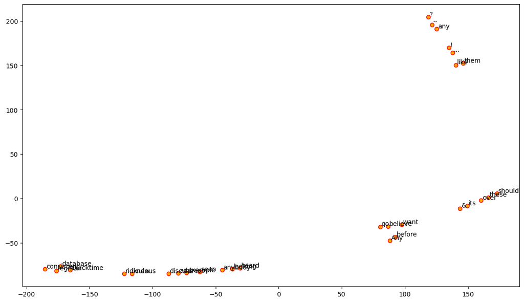

```python
from sklearn.manifold import TSNE
from matplotlib import pyplot as plt

# 从文本文档中随机选出几个单词获取其近义词
# 进行二维词嵌入可视化示例
temp = ['ridiculous','example','looking','consistent','address']

similar_words = {search_term:[item[0]
                 for item in multi3_w2v.wv.most_similar([search_term],topn=5)]
                      for search_term in temp}

similar_words
words = sum([[k] + v for k,v in similar_words.items()],[])
wvs = multi3_w2v.wv[words]
tsne = TSNE(n_components=2, random_state=0, n_iter=10000, perplexity=2, init='pca', learning_rate='auto')
np.set_printoptions(suppress=True)
T = tsne.fit_transform(wvs)
labels = words
plt.figure(figsize=(14,8))
plt.scatter(T[:,0],T[:,1],c="orange",edgecolors="r")
for label,x,y in zip(labels,T[:,0],T[:,1]):
    plt.annotate(label,xy=(x+1,y+1),xytext=(0,0),textcoords='offset points')
```

### 2.基于词嵌入向量对 multi3 和 multi5 进行分类。

a. 基于词嵌入向量（设定适当参数，文档向量为其所含词的词嵌入向量的平均），用 SVM 进行分类，得到 accuracy。

```python
# 以下使用CBOW模型得到的文档向量进行SVM分类
from sklearn.svm import LinearSVC
from sklearn.model_selection import train_test_split

# 划分训练集和测试集
# .tolist() 转为list，使用np.array时svm报错
train_vector,test_vector,train_label_nums,test_label_nums,\
train_label_names,test_label_names = train_test_split(All_document_vector[0:600],
                                                    np.array(multi3['Target Label']),
                                                    np.array(multi3['Target Name']),
                                                    test_size=0.33,random_state=42)

svm = LinearSVC(penalty='l2',C=1,random_state=42)
svm.fit(train_vector,train_label_nums)
# 在测试集上评估模型准确度
accuracy = svm.score(test_vector, test_label_nums)
print("multi3测试集准确度:", accuracy)
# 以下使用CBOW模型得到的文档向量进行SVM分类
from sklearn.svm import LinearSVC
from sklearn.model_selection import train_test_split

# 划分训练集和测试集
# .tolist() 转为list，使用np.array时svm报错
train_vector,test_vector,train_label_nums,test_label_nums,\
train_label_names,test_label_names = train_test_split(All_document_vector[600:1600],
                                                    np.array(multi5['Target Label']),
                                                    np.array(multi5['Target Name']),
                                                    test_size=0.33,random_state=42)

svm = LinearSVC(penalty='l2',C=1,random_state=42)
svm.fit(train_vector,train_label_nums)
# 在测试集上评估模型准确度
accuracy = svm.score(test_vector, test_label_nums)
print("multi5测试集准确度:", accuracy)
```

```
multi3测试集准确度: 0.45454545454545453
multi5测试集准确度: 0.3575757575757576
```

b. 基于 TFIDF 词袋模型用 SVM 对上面两个数据集进行分类，对比a 中结果并讨论。

```python
import nltk
import spacy
from nltk.tokenize.toktok import ToktokTokenizer
import re

tokenizer = ToktokTokenizer()
# 默认英语停用词表
stopword_list = nltk.corpus.stopwords.words('english')
# 定义Spacy模型nlp
nlp = spacy.load('en_core_web_sm')

# 词干提取
def stem_text(text):
    # 实例化PorterStemmer对象
    ps = nltk.porter.PorterStemmer()
    # 对text进行分词
    tokens = tokenizer.tokenize(text)
    # strip()方法去掉字符串头尾多余的空格等字符
    stem_token = [ps.stem(token.strip()) for token in tokens]
    text = ' '.join(stem_token)
    return text

# 词性还原
def lemmatize_text(text):
    # 使用nlp模型对输入进行分析
    text = nlp(text)
    # 对text的每一个token调用.lemma_方法得到词形还原结果
    lemma_word = [word.lemma_ if word.lemma_ !='-PRON' else word.text for word in text]
    text = ' '.join(lemma_word)
    return text

# 去停用词
def remove_stopwords(text,is_lower_case = False):
    # 对text进行分词
    tokens = tokenizer.tokenize(text)
    # strip()方法去掉字符串头尾多余的空格等字符
    tokens = [token.strip() for token in tokens]
    # 去停用词，需要判断大小写
    if is_lower_case:
        filtered_tokens = [token for token in tokens if token not in stopword_list]
    else:
        filtered_tokens = [token for token in tokens if token.lower() not in stopword_list]
    filtered_text = ' '.join(filtered_tokens)
    return filtered_text

# 默认进行词干提取和去停用词
def EngPreprocess(corpus,text_stemming=True,text_lemmation=False,stopword_removal=True,text_lower_case=False):
    normalized_corpus = []
    # 遍历每个文档
    for doc in corpus:
        # 去除标点符号
        doc = re.sub(r'[^\w\s]', '', doc)
        # 词干提取
        if text_stemming:
            doc = stem_text(doc)
        # 词形还原
        if text_lemmation:
            doc = lemmatize_text(doc)
        # 去停用词
        if stopword_removal:
            doc = remove_stopwords(doc,is_lower_case=text_lower_case)
        normalized_corpus.append(doc)
    return normalized_corpus

# 此处预处理只是去停用词
multi3_article = EngPreprocess(multi3['Article'],False,False,True,False)
multi3['Clean Article'] = multi3_article
multi5_article = EngPreprocess(multi5['Article'],False,False,True,False)
multi5['Clean Article'] = multi5_article
multi3.head()
multi5.head()
from sklearn.feature_extraction.text import TfidfVectorizer
# TF-IDF表示
tv = TfidfVectorizer(min_df = 0.,max_df = 1.0,norm='l2',use_idf=True,smooth_idf=True)
tt_multi3_features  = tv.fit_transform(multi3_article)
tt_multi3_features = tt_multi3_features.toarray()

tt_multi5_features  = tv.fit_transform(multi5_article)
tt_multi5_features = tt_multi5_features.toarray()
# 划分训练集和测试集
train_vector,test_vector,train_label_nums,test_label_nums,\
train_label_names,test_label_names = train_test_split(tt_multi3_features,
                                                    np.array(multi3['Target Label']),
                                                    np.array(multi3['Target Name']),
                                                    test_size=0.33,random_state=42)

svm = LinearSVC(penalty='l2',C=1,random_state=42)
svm.fit(train_vector,train_label_nums)
# 在测试集上评估模型准确度
accuracy = svm.score(test_vector, test_label_nums)
print("multi3 TFIDF测试集准确度:", accuracy)
# 划分训练集和测试集
train_vector,test_vector,train_label_nums,test_label_nums,\
train_label_names,test_label_names = train_test_split(tt_multi5_features,
                                                    np.array(multi5['Target Label']),
                                                    np.array(multi5['Target Name']),
                                                    test_size=0.33,random_state=42)

svm = LinearSVC(penalty='l2',C=1,random_state=42)
svm.fit(train_vector,train_label_nums)
# 在测试集上评估模型准确度
accuracy = svm.score(test_vector, test_label_nums)
print("multi5 TFIDF测试集准确度:", accuracy)
```

```
multi3 TFIDF测试集准确度: 0.9090909090909091
multi5 TFIDF测试集准确度: 0.8696969696969697
```

```python
# 前文中已经将两者合并过，因此直接使用即可

# 划分训练集和测试集
# .tolist() 转为list，使用np.array时svm报错
train_vector,test_vector,train_label_nums,test_label_nums,\
train_label_names,test_label_names = train_test_split(All_document_vector,
                                                    np.array(merged_multi['Target Label']),
                                                    np.array(merged_multi['Target Name']),
                                                    test_size=0.33,random_state=42)

svm = LinearSVC(penalty='l2',C=1,random_state=42)
svm.fit(train_vector,train_label_nums)
# 在测试集上评估模型准确度
accuracy = svm.score(test_vector, test_label_nums)
print("测试集准确度:", accuracy)
```

```
测试集准确度: 0.38825757575757575
```

d. 以 TFIDF 为权重，对每个文档所含词向量进行加权平均得到文档向量，进行 SVM 分类，对比前面结果。

```python
from sklearn.feature_extraction.text import TfidfVectorizer
from sklearn.svm import LinearSVC
from sklearn.model_selection import train_test_split
import numpy as np

# 将词向量进行加权平均得到文档向量
def calculate_weighted_average(document_vectors, tfidf_weights):
    weighted_average_vectors = []
    for doc_vec, weights in zip(document_vectors, tfidf_weights):
        if np.sum(weights) != 0:  # 检查权重数组是否全为零
            weighted_average_vectors.append(np.average(doc_vec, weights=weights, axis=0))
        else:
            weighted_average_vectors.append(np.zeros_like(doc_vec))  # 若权重数组全为零，则返回全零的文档向量
    return np.array(weighted_average_vectors)

# 使用TF-IDF表示
tv = TfidfVectorizer(min_df=0., max_df=1.0, norm='l2', use_idf=True, smooth_idf=True)
tt_multi3_features = tv.fit_transform(multi3_article)
tt_multi5_features = tv.fit_transform(multi5_article)

# 划分训练集和测试集
train_vector, test_vector, train_label_nums, test_label_nums, \
train_label_names, test_label_names = train_test_split(tt_multi3_features,
                                                      np.array(multi3['Target Label']),
                                                      np.array(multi3['Target Name']),
                                                      test_size=0.33, random_state=42)

# 计算TF-IDF加权平均文档向量
train_vectors = calculate_weighted_average(train_vector.toarray(), train_vector.toarray())
test_vectors = calculate_weighted_average(test_vector.toarray(), test_vector.toarray())

# SVM模型训练和预测
svm = LinearSVC(penalty='l2', C=1, random_state=42)
svm.fit(train_vectors, train_label_nums)
accuracy = svm.score(test_vectors, test_label_nums)
print("multi3 TFIDF加权平均测试集准确度:", accuracy)

# 划分训练集和测试集
train_vector, test_vector, train_label_nums, test_label_nums, \
train_label_names, test_label_names = train_test_split(tt_multi5_features,
                                                      np.array(multi5['Target Label']),
                                                      np.array(multi5['Target Name']),
                                                      test_size=0.33, random_state=42)

# 计算TF-IDF加权平均文档向量
train_vectors = calculate_weighted_average(train_vector.toarray(), train_vector.toarray())
test_vectors = calculate_weighted_average(test_vector.toarray(), test_vector.toarray())

# SVM模型训练和预测
svm = LinearSVC(penalty='l2', C=1, random_state=42)
svm.fit(train_vectors, train_label_nums)
accuracy = svm.score(test_vectors, test_label_nums)
```

[output not shown]

### 2.预训练词向量

```python
import gensim.downloader
import numpy as np

# 加载GloVe预训练词向量
glove_vectors = gensim.downloader.load('glove-twitter-200')
```

```python
# 对于3类数据集进行分词处理
multi3_tokenized_corpus = [tokenizer.tokenize(document) for document in multi3['Article']]

# 定义词向量模型的参数
feature_size = 200

# 初始化文档嵌入矩阵
document_embeddings = np.zeros((len(multi3_tokenized_corpus), feature_size))

# 对每个文档进行词嵌入并计算文档嵌入向量
for i, tokenized_doc in enumerate(multi3_tokenized_corpus):
    doc_embedding = np.zeros(feature_size)
    num_tokens = 0

    # 对文档中的每个词进行嵌入
    for token in tokenized_doc:
        if token in glove_vectors:
            token_embedding = glove_vectors[token]
            doc_embedding += token_embedding
            num_tokens += 1

    if num_tokens > 0:
        # 计算平均词嵌入
        doc_embedding /= num_tokens

    document_embeddings[i] = doc_embedding
import numpy as np
from sklearn.metrics.pairwise import euclidean_distances

# 计算一个类别的紧凑度
def calculate_compactness(document_vectors):
    # 将 document_vectors 中的向量转换为二维数组（每行表示一个向量）
    document_matrix = np.vstack(document_vectors.values)
    # 计算欧式距离的平方
    distance_matrix = np.square(euclidean_distances(document_matrix))
    # 计算紧凑度
    compactness = distance_matrix.sum()
    return compactness

# 所有的类别类型
categories = ['comp.graphics', 'rec.autos','comp.windows.x', 'rec.sport.hockey','rec.autos','talk.politics.guns']
compactness_list = []

# 遍历所有类别
for category in categories:
    # 获取该类别中的文档的平均向量
    document_vectors = merged_multi.loc[merged_multi['Target Name'] == category, 'Mean Document Vector']
    # 计算该类别的紧凑度
    compactness = calculate_compactness(document_vectors)
    compactness_list.append(compactness)

# 输出每个类别的紧凑度
for i in range(len(categories)):
    print('类别', categories[i], '的紧凑度为:', compactness_list[i])
```

[output not shown]